# Milestone 4

#### Objective:

- Audit a model for bias when the protected class is not available.

#### Workflow:

- Introduction
- Set up problem
- Load data and display primary and secondary sets
- Load model to audit for bias
- Train model from proxy variables to predict the protected class
- Assess the model bias
- Report your findings

#### Importance to Project:

- Very often, protected class information is not available when you are auditing for bias or removing bias.
- In these cases, the task becomes much more challenging.
- You might not have access to the protected class information either because you can only see the model itself and not the underlying data, or because even the original creators don't know the protected class status of each row.
- While auditing or mitigating bias without direct access to the protected class introduces a level of uncertainty, we can still reach some conclusions about biased models, but must be open about the uncertainty.
- The most powerful techniques are beyond the scope of this milestone. However, knowing some baseline techniques can be helpful in easy cases and can help guide a decision whether to pursue a more in-depth audit.

#### Resources:

- You should be able to proceed with this milestone without any additional resources. However, the following resources will provide useful context and more information.
  - https://arxiv.org/pdf/1906.00285.pdf]
  - https://www.youtube.com/watch?v=z-ZI1VoA-O0]
  - https://arxiv.org/pdf/1811.11154.pdf
  - https://github.com/cfpb/proxy-methodology
  - https://amstat.tandfonline.com/doi/full/10.1080/2330443X.2018.1427012

## Introduction

We can still assess algorithmic fairness when the protected class is unobserved, provided we have some way to deduce the protected class from the available data. The most famous real-world example of this is the BISG proxy, which uses a Naive Bayes model to predict race membership based on name and zipcode. As Chen et al note, "This methodology notably supported a $98 million fine against a major auto loan lender".

While the BISG proxy methodology is still used and developed, recent scholarship in machine fairness demonstrates some serious shortcomings and some new directions for modelling without access to protected class data. The fundamental issue is that proxy models, unless highly accurate, could skew the audit. For instance, Chen et al showed the BISG methodology has been shown to overestimate true disparities. In summary, we need to exercise great care when building proxy models and imputing protected class data.

In terms of new directions for assessing algorithmic fairness when the protected class is unobserved, an interesting paper released this year entitled "Assessing Algorithmic Fairness with Unobserved Protected Class Using Data Combination" describes a methodology for estimating confidence intervals for bias metrics. While the methodology is too complex to review here, in the course of this milestone it will become clear why confidence intervals are so useful. It is well worth considering for any bias audit where the protected class is unavailable.

Regardless of the chosen methodology, the general setup requires the following datasets:

- a primary dataset, which contains input variables to the model and the model's final prediction
- a secondary dataset, which contains some proxy variables which overlap with the primary dataset, and does contain the protected class labels

An example of a primary set and secondary set in a lending context with potential racial bias can be found below (proxy variables are surname and zipcode, as in BISG, and they can be found in both the primary and secondary sets)

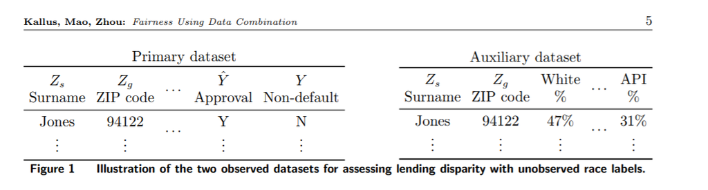

## Setting up the problem

In our example, we are interested in evaluating the bias in a model which determines personalized warfarin dosage. A similar model built on the same dataset has already been audited using state-of-the-art partial identification sets in a recent paper by Kallus, Mao and Zhou. We will be using a simpler methodology.

Warfarin is the world's most common anticoagulant, but the correct dosage for the desired effect changes significantly from person to person. Too little warfarin will fail to produce a coagulant effect, while too much warfarin can cause dangerous bleeding, stroke and death.

In these circumstances, dosage by trial and error is dangerous, so the medical community has built models to predict the ideal warfarin dosage. These models can be found in section 8.2 of Kallus, Mao, Zhou. The makers of the models note that genetic factors correlated with race are predictive of the outcome, so we can expect dosage and dosage prediction to differ by race. We are interested to audit the model's bias.

## Investigating primary and secondary sets

```python
import pandas as pd
import pickle
from sklearn.ensemble import RandomForestClassifier
from sklearn.model_selection import train_test_split
import sklearn
```

```python
genes = ['Cyp2C9 genotypes', 'Genotyped QC Cyp2C9*2', 'Genotyped QC Cyp2C9*3',
       'Combined QC CYP2C9','VKORC1 genotype: -1639 G>A (3673); chr16:31015190; rs9923231; C/T',
       'VKORC1 QC genotype: -1639 G>A (3673); chr16:31015190; rs9923231; C/T',
       'VKORC1 genotype: 497T>G (5808); chr16:31013055; rs2884737; A/C',
       'VKORC1 QC genotype: 497T>G (5808); chr16:31013055; rs2884737; A/C',
       'VKORC1 genotype: 1173 C>T(6484); chr16:31012379; rs9934438; A/G',
       'VKORC1 QC genotype: 1173 C>T(6484); chr16:31012379; rs9934438; A/G',
       'VKORC1 genotype: 1542G>C (6853); chr16:31012010; rs8050894; C/G',
       'VKORC1 QC genotype: 1542G>C (6853); chr16:31012010; rs8050894; C/G',
       'VKORC1 genotype: 3730 G>A (9041); chr16:31009822; rs7294;  A/G',
       'VKORC1 QC genotype: 3730 G>A (9041); chr16:31009822; rs7294;  A/G',
       'VKORC1 genotype: 2255C>T (7566); chr16:31011297; rs2359612; A/G',
       'VKORC1 QC genotype: 2255C>T (7566); chr16:31011297; rs2359612; A/G',
       'VKORC1 genotype: -4451 C>A (861); Chr16:31018002; rs17880887; A/C',
       'VKORC1 QC genotype: -4451 C>A (861); Chr16:31018002; rs17880887; A/C',
       'CYP2C9 consensus', 'VKORC1 -1639 consensus', 'VKORC1 497 consensus',
       'VKORC1 1173 consensus', 'VKORC1 1542 consensus',
       'VKORC1 3730 consensus', 'VKORC1 2255 consensus',
       'VKORC1 -4451 consensus']
medication = ['Aspirin', 'Acetaminophen or Paracetamol (Tylenol)',
       'Was Dose of Acetaminophen or Paracetamol (Tylenol) >1300mg/day',
       'Simvastatin (Zocor)', 'Atorvastatin (Lipitor)', 'Fluvastatin (Lescol)',
       'Lovastatin (Mevacor)', 'Pravastatin (Pravachol)',
       'Rosuvastatin (Crestor)', 'Cerivastatin (Baycol)',
       'Amiodarone (Cordarone)', 'Carbamazepine (Tegretol)',
       'Phenytoin (Dilantin)', 'Rifampin or Rifampicin',
       'Sulfonamide Antibiotics', 'Macrolide Antibiotics',
       'Anti-fungal Azoles', 'Herbal Medications, Vitamins, Supplements']
```

### Load the primary set (primary.csv), the secondary set (secondary.csv), and the model (model.pkl)

```python
primary = pd.read_csv('data/primary.csv')
display(primary)
secondary = pd.read_csv('data/secondary.csv')
display(secondary)
model = pickle.load(open('data/milestone_4_model.pkl','rb'))
```

|  | Unnamed: 0 | Project Site | Age | Height (cm) | Weight (kg) | Diabetes | Congestive Heart Failure and/or Cardiomyopathy | Valve Replacement | Aspirin | Acetaminophen or Paracetamol (Tylenol) | ... | VKORC1 QC genotype: -4451 C>A (861); Chr16:31018002; rs17880887; A/C | CYP2C9 consensus | VKORC1 -1639 consensus | VKORC1 497 consensus | VKORC1 1173 consensus | VKORC1 1542 consensus | VKORC1 3730 consensus | VKORC1 2255 consensus | VKORC1 -4451 consensus | target |
| --- | --- | --- | --- | --- | --- | --- | --- | --- | --- | --- | --- | --- | --- | --- | --- | --- | --- | --- | --- | --- | --- |
| 0 | 290 | 1 | 75.0 | 172.720 | 72.6 | -1.0 | -1.0 | -1.0 | 1.0 | -1.0 | ... | 3.0 | 4.0 | 2.0 | 2.0 | 3.0 | 2.0 | 1.0 | 3.0 | 3.0 | True |
| 1 | 2638 | 7 | 85.0 | 165.100 | 72.6 | 0.0 | 0.0 | 0.0 | 1.0 | -1.0 | ... | 3.0 | 4.0 | 3.0 | 3.0 | 3.0 | 1.0 | 3.0 | 3.0 | 3.0 | False |
| 2 | 420 | 1 | 25.0 | 162.560 | 72.6 | -1.0 | -1.0 | -1.0 | 0.0 | -1.0 | ... | 3.0 | 4.0 | 1.0 | 3.0 | 3.0 | 3.0 | 3.0 | 3.0 | 3.0 | False |
| 3 | 1256 | 3 | 55.0 | 172.974 | 76.0 | -1.0 | 0.0 | 1.0 | -1.0 | -1.0 | ... | 3.0 | 0.0 | 0.0 | 3.0 | 2.0 | 0.0 | 2.0 | 2.0 | 3.0 | False |
| 4 | 2744 | 8 | 55.0 | 160.000 | 55.0 | 1.0 | 0.0 | 1.0 | 0.0 | 0.0 | ... | 3.0 | 0.0 | 0.0 | 3.0 | 2.0 | 3.0 | 2.0 | 3.0 | 3.0 | True |
| ... | ... | ... | ... | ... | ... | ... | ... | ... | ... | ... | ... | ... | ... | ... | ... | ... | ... | ... | ... | ... | ... |
| 1258 | 1958 | 5 | 65.0 | 181.102 | 77.7 | 0.0 | 0.0 | 0.0 | 0.0 | 0.0 | ... | 3.0 | 0.0 | 2.0 | 2.0 | 3.0 | 2.0 | 1.0 | 3.0 | 1.0 | True |
| 1259 | 1261 | 3 | 55.0 | 182.118 | 57.0 | -1.0 | 0.0 | 1.0 | -1.0 | -1.0 | ... | 3.0 | 0.0 | 0.0 | 3.0 | 2.0 | 0.0 | 2.0 | 2.0 | 3.0 | False |
| 1260 | 3784 | 13 | 75.0 | -1.000 | -1.0 | -1.0 | -1.0 | -1.0 | 0.0 | -1.0 | ... | 2.0 | 11.0 | 3.0 | 2.0 | 2.0 | 0.0 | 2.0 | 2.0 | 2.0 | False |
| 1261 | 3232 | 10 | 45.0 | -1.000 | 88.0 | 0.0 | 0.0 | 0.0 | -1.0 | 0.0 | ... | 3.0 | 0.0 | 0.0 | 3.0 | 2.0 | 0.0 | 3.0 | 2.0 | 3.0 | False |
| 1262 | 2255 | 6 | 35.0 | 154.940 | 76.6 | -1.0 | -1.0 | -1.0 | -1.0 | -1.0 | ... | 3.0 | 0.0 | 2.0 | 3.0 | 3.0 | 3.0 | 3.0 | 3.0 | 3.0 | True |

1263 rows × 57 columns

|  | Unnamed: 0 | Cyp2C9 genotypes | Genotyped QC Cyp2C9*2 | Genotyped QC Cyp2C9*3 | Combined QC CYP2C9 | VKORC1 genotype: -1639 G>A (3673); chr16:31015190; rs9923231; C/T | VKORC1 QC genotype: -1639 G>A (3673); chr16:31015190; rs9923231; C/T | VKORC1 genotype: 497T>G (5808); chr16:31013055; rs2884737; A/C | VKORC1 QC genotype: 497T>G (5808); chr16:31013055; rs2884737; A/C | VKORC1 genotype: 1173 C>T(6484); chr16:31012379; rs9934438; A/G | ... | Cerivastatin (Baycol) | Amiodarone (Cordarone) | Carbamazepine (Tegretol) | Phenytoin (Dilantin) | Rifampin or Rifampicin | Sulfonamide Antibiotics | Macrolide Antibiotics | Anti-fungal Azoles | Herbal Medications, Vitamins, Supplements | Race (OMB) |
| --- | --- | --- | --- | --- | --- | --- | --- | --- | --- | --- | --- | --- | --- | --- | --- | --- | --- | --- | --- | --- | --- |
| 0 | 3571 | 4.0 | 3.0 | 3.0 | 6.0 | 1.0 | 3.0 | 1.0 | 3.0 | 1.0 | ... | 0.0 | 0.0 | 0.0 | 0.0 | 0.0 | 0.0 | 0.0 | 0.0 | -1.0 | White |
| 1 | 1763 | 0.0 | 0.0 | 0.0 | 0.0 | 2.0 | 2.0 | 2.0 | 2.0 | 3.0 | ... | 0.0 | 0.0 | 0.0 | 0.0 | 0.0 | 0.0 | 0.0 | 0.0 | 0.0 | White |
| 2 | 3702 | 0.0 | 0.0 | 0.0 | 0.0 | 0.0 | 0.0 | 0.0 | 0.0 | 2.0 | ... | 0.0 | 0.0 | 0.0 | 0.0 | 0.0 | 0.0 | 0.0 | 0.0 | -1.0 | White |
| 3 | 4767 | 0.0 | 3.0 | 3.0 | 6.0 | 3.0 | 3.0 | 3.0 | 3.0 | 2.0 | ... | -1.0 | -1.0 | -1.0 | -1.0 | -1.0 | -1.0 | -1.0 | -1.0 | -1.0 | Asian |
| 4 | 2062 | 4.0 | 1.0 | 0.0 | 1.0 | 1.0 | 0.0 | 3.0 | 0.0 | 3.0 | ... | -1.0 | -1.0 | -1.0 | -1.0 | -1.0 | -1.0 | -1.0 | -1.0 | -1.0 | White |
| ... | ... | ... | ... | ... | ... | ... | ... | ... | ... | ... | ... | ... | ... | ... | ... | ... | ... | ... | ... | ... | ... |
| 2520 | 5513 | 0.0 | 3.0 | 3.0 | 6.0 | 3.0 | 3.0 | 3.0 | 3.0 | 0.0 | ... | -1.0 | 0.0 | 0.0 | 0.0 | 0.0 | 0.0 | 0.0 | 0.0 | -1.0 | Black or African American |
| 2521 | 226 | 0.0 | 3.0 | 3.0 | 6.0 | 2.0 | 3.0 | 2.0 | 3.0 | 3.0 | ... | -1.0 | 0.0 | -1.0 | -1.0 | -1.0 | -1.0 | -1.0 | -1.0 | -1.0 | White |
| 2522 | 2728 | 0.0 | 3.0 | 3.0 | 6.0 | 3.0 | 3.0 | 3.0 | 3.0 | 3.0 | ... | -1.0 | 0.0 | -1.0 | -1.0 | -1.0 | -1.0 | -1.0 | -1.0 | -1.0 | White |
| 2523 | 2637 | 0.0 | 3.0 | 3.0 | 6.0 | 3.0 | 3.0 | 3.0 | 3.0 | 3.0 | ... | -1.0 | 0.0 | -1.0 | -1.0 | -1.0 | -1.0 | -1.0 | -1.0 | -1.0 | White |
| 2524 | 2965 | 5.0 | 3.0 | 3.0 | 6.0 | 0.0 | 3.0 | 3.0 | 3.0 | 2.0 | ... | 0.0 | 0.0 | 0.0 | 0.0 | 0.0 | 0.0 | 0.0 | 0.0 | 0.0 | Asian |

2525 rows × 46 columns

## Given the supplied training columns, use the model to predict warfarin dosage for the primary set

```python
train_cols = ['Project Site', 'Age', 'Height (cm)', 'Weight (kg)', 'Diabetes',
       'Congestive Heart Failure and/or Cardiomyopathy', 'Valve Replacement',
       'Aspirin', 'Acetaminophen or Paracetamol (Tylenol)',
       'Was Dose of Acetaminophen or Paracetamol (Tylenol) >1300mg/day',
       'Simvastatin (Zocor)', 'Atorvastatin (Lipitor)', 'Fluvastatin (Lescol)',
       'Lovastatin (Mevacor)', 'Pravastatin (Pravachol)',
       'Rosuvastatin (Crestor)', 'Cerivastatin (Baycol)',
       'Amiodarone (Cordarone)', 'Carbamazepine (Tegretol)',
       'Phenytoin (Dilantin)', 'Rifampin or Rifampicin',
       'Sulfonamide Antibiotics', 'Macrolide Antibiotics',
       'Anti-fungal Azoles', 'Herbal Medications, Vitamins, Supplements',
       'Target INR', 'Subject Reached Stable Dose of Warfarin',
       'INR on Reported Therapeutic Dose of Warfarin', 'Current Smoker',
       'Cyp2C9 genotypes', 'Genotyped QC Cyp2C9*2', 'Genotyped QC Cyp2C9*3',
       'Combined QC CYP2C9',
       'VKORC1 genotype: -1639 G>A (3673); chr16:31015190; rs9923231; C/T',
       'VKORC1 QC genotype: -1639 G>A (3673); chr16:31015190; rs9923231; C/T',
       'VKORC1 genotype: 497T>G (5808); chr16:31013055; rs2884737; A/C',
       'VKORC1 QC genotype: 497T>G (5808); chr16:31013055; rs2884737; A/C',
       'VKORC1 genotype: 1173 C>T(6484); chr16:31012379; rs9934438; A/G',
       'VKORC1 QC genotype: 1173 C>T(6484); chr16:31012379; rs9934438; A/G',
       'VKORC1 genotype: 1542G>C (6853); chr16:31012010; rs8050894; C/G',
       'VKORC1 QC genotype: 1542G>C (6853); chr16:31012010; rs8050894; C/G',
       'VKORC1 genotype: 3730 G>A (9041); chr16:31009822; rs7294;  A/G',
       'VKORC1 QC genotype: 3730 G>A (9041); chr16:31009822; rs7294;  A/G',
       'VKORC1 genotype: 2255C>T (7566); chr16:31011297; rs2359612; A/G',
       'VKORC1 QC genotype: 2255C>T (7566); chr16:31011297; rs2359612; A/G',
       'VKORC1 genotype: -4451 C>A (861); Chr16:31018002; rs17880887; A/C',
       'VKORC1 QC genotype: -4451 C>A (861); Chr16:31018002; rs17880887; A/C',
       'CYP2C9 consensus', 'VKORC1 -1639 consensus', 'VKORC1 497 consensus',
       'VKORC1 1173 consensus', 'VKORC1 1542 consensus',
       'VKORC1 3730 consensus', 'VKORC1 2255 consensus',
       'VKORC1 -4451 consensus']

primary['prediction'] = model.predict(primary[train_cols])
```

## Train a proxy model on the secondary set to impute the missing protected class data

```python
X, y = secondary[medication+genes],secondary['Race (OMB)']

X_train, X_test, y_train, y_test = train_test_split(
     secondary, y, test_size=0.33, random_state=42)

rfc_race_medication = RandomForestClassifier()
rfc_race_medication.fit(X_train[medication], y_train)

print(sklearn.metrics.confusion_matrix(y_test, rfc_race_medication.predict(X_test[medication])))
```

```
[[236   0   5]
 [  9  21  57]
 [ 76  16 414]]
```

```python
rfc_race_genes = RandomForestClassifier()
rfc_race_genes.fit(X_train[genes], y_train)

sklearn.metrics.confusion_matrix(y_test, rfc_race_genes.predict(X_test[genes]))
```

```
array([[238,   0,   3],
       [  0,  60,  27],
       [ 10,  28, 468]], dtype=int64)
```

```python
modelling_cols = [col for col in secondary.columns if col!='Race (OMB)']

X, y = secondary[medication+genes],secondary['Race (OMB)']

X_train, X_test, y_train, y_test = train_test_split(
     X, y, test_size=0.33, random_state=42)

rfc_race_all = RandomForestClassifier()
rfc_race_all.fit(X_train, y_train)

sklearn.metrics.confusion_matrix(y_test, rfc_race_all.predict(X_test))
```

```
array([[238,   0,   3],
       [  0,  57,  30],
       [  2,  21, 483]], dtype=int64)
```

## Add a race column to the primary dataset by using the proxy model with the best performance

Since the proxy columns are present in the primary and secondary sets, you can now predict the race of each row in the primary dataset

```python
# primary['race'] = rfc_race_medication.predict(primary[medication])
# primary['race'] = rfc_race_genes.predict(primary[genes])
primary['race'] = rfc_race_all.predict(primary[medication+genes])
```

## Assess the model bias with the best proxy

In a real-world context, we will usually have some idea of what specific bias metrics we want to measure and report back on. In this case, we can take some guidance from Kallus, Mao, and Zhou's paper and look to the bias metrics they investigated for this set. The authors in that case study were interested in the distribution of high dosage recommendations by race ("demographic disparity, see section 8.2 of https://arxiv.org/pdf/1906.00285.pdf), and the distribution of true positive rates by race.

- Grouping the dataset by race, observe whether the distribution of high dosage recommendations is uniform
- Using the tpr helper function, compare the true positive rates for each race. Does disparity exist?

```python
def tpr(dataset,race): #race can be "Black or African American", "White", or "Asian",
    race_incl_subset = dataset[dataset['race']==race]
    race_excl_subset = dataset[dataset['race']!=race]
    tpr = len(race_incl_subset[race_incl_subset['prediction'] & race_incl_subset['target']]) / \
    len(race_incl_subset[race_incl_subset['prediction']])
    tpr_other = len(race_excl_subset[race_excl_subset['prediction'] & race_excl_subset['target']]) / \
    len(race_excl_subset[race_excl_subset['prediction']])
    return ('True positive rate for %s: %s' % (race, tpr),
           'True positive rate for non-%s: %s' % (race, tpr_other),
           'Disparity in True positive rate: %s' % (tpr-tpr_other))
```

```python
primary.groupby('race').agg({'prediction':'mean'})
```

| race | prediction |
| --- | --- |
| Asian | 0.061905 |
| Black or African American | 0.736842 |
| White | 0.247326 |

```python
tpr(primary,'Asian')
```

```
('True positive rate for Asian: 0.46153846153846156',
 'True positive rate for non-Asian: 0.6509803921568628',
 'Disparity in True positive rate: -0.1894419306184012')
```

```python
tpr(primary,'White')
```

```
('True positive rate for White: 0.654054054054054',
 'True positive rate for non-White: 0.59375',
 'Disparity in True positive rate: 0.060304054054054035')
```

```python
tpr(primary,'Black or African American')
```

```
('True positive rate for Black or African American: 0.6428571428571429',
 'True positive rate for non-Black or African American: 0.6303317535545023',
 'Disparity in True positive rate: 0.012525389302640577')
```

## Add a race column to the primary dataset by using the proxy model with the worst performance

```python
#Since the proxy columns are present in the primary and secondary sets,
#you can now predict the race of each row in the primary dataset

primary['race'] = rfc_race_medication.predict(primary[medication])
# primary['race'] = rfc_race_genes.predict(primary[genes])
# primary['race'] = rfc_race_all.predict(primary[medication+genes])
```

## Assess the model bias using the race imputation from the worst proxy

```python
primary.groupby('race').agg({'prediction':'mean'})
```

| race | prediction |
| --- | --- |
| Asian | 0.089015 |
| Black or African American | 0.612245 |
| White | 0.297376 |

```python
tpr(primary,'Asian')
```

```
('True positive rate for Asian: 0.5531914893617021',
 'True positive rate for non-Asian: 0.6495726495726496',
 'Disparity in True positive rate: -0.09638116021094745')
```

```python
tpr(primary,'White')
```

```
('True positive rate for White: 0.6715686274509803',
 'True positive rate for non-White: 0.5324675324675324',
 'Disparity in True positive rate: 0.13910109498344791')
```

```python
tpr(primary,'Black or African American')
```

```
('True positive rate for Black or African American: 0.5',
 'True positive rate for non-Black or African American: 0.649402390438247',
 'Disparity in True positive rate: -0.149402390438247')
```

## Optional: Reflect on the importance of having a highly accurate proxy when modelling without access to protected class data

Our conclusions about the demographic disparity, the true positive rate disparity, or any other bias metric, are greatly reliant on the accuracy of our proxy model if we choose this methodology. Though the best proxy (genetic+medication) and the worst proxy (medication only) lead us to the conclusion that there is a demographic disparity, the proxy choice still influences the magnitude of that disparity (eg in my modelling, Asians have a 6% allocation of high dosages in the best proxy and 9% in the worst).

Looking at the True Positive Rates, the choice of proxy completely changes the outcome. Using the best proxy, in my modelling, Asians are substantially disadvantaged in that they will be incorrectly given a high dosage recommendation by the model 18% more than the remaining population. Using the worst proxy, this disadvantage still exists but is half the magnitude - and both White and Black/African American populations seem to have a higher magnitude of True Positive Rate Disparity. If we only had access to medication data (which forms the worst proxy), we might reach completely different conclusions

In terms of this dataset, we can conclude that there is a strong possibility of a demographic disparity in the model, which may or may not be unwanted. We can also conclude that there is a possibility that, for Asian patients, the model has a higher than usual likelihood to recommend high dosages when low dosages are suitable.

In general, though proxy models are a valuable tool for auditing bias when the protected class feature is not available, we are highly reliant on the proxy models accuracy. Fortunately, our best proxy model here was highly accurate. Newer methodologies allow us to incorporate confidence intervals when using proxy models, which is particularly important when our proxy models are not very accurate. With these confidence intervals, we are able to better understand how inaccuracy of our proxies affects the certainty of our results. :

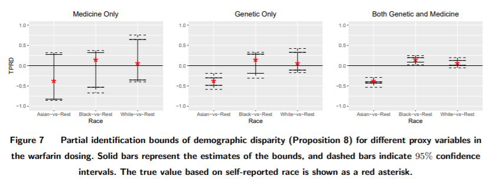